# AIML-505: Large Language Models and Generative Artificial Intelligence

## Workshop 1: Foundations of Generative AI and Large Language Models

### Indiana Wesleyan University

#### Dr. Eskinder Belete Summer 2026

1. Introduction
   - Workshop Overview
   - Learning Objectives
2. Key Terminologies for Workshop 1
   - Artificial Intelligence (AI)
   - Generative Artificial Intelligence
   - Large Language Models (LLMs)
   - Transformer Architecture
   - Prompt Engineering
   - Tokenization
   - Context Window
   - Multimodal AI
   - Visual Summary: The Generative AI Ecosystem
3. Interactive Demonstrations
   - Setting Up the Python Environment
   - Importing Required Libraries
   - Exploring the Microsoft Enterprise Knowledge Repository
   - Loading the Microsoft Annual Report
   - Understanding Unstructured Text Data
   - Prompt Engineering Demonstration
   - Tokenization Demonstration
   - AI-Powered Text Summarization
   - Business Leadership Example
4. Microsoft Enterprise Case Study
   - Company Overview
   - Why Microsoft?
   - Annual Report Overview
   - Executive Leadership Perspectives
5. Summary
6. References and Further Reading

## 1. Introduction

Generative Artificial Intelligence (Generative AI) represents one of the most significant technological advancements in contemporary computing, fundamentally transforming how organizations create, analyze, and interact with information. Unlike traditional artificial intelligence systems that primarily focus on prediction or classification, generative AI models are capable of producing novel content—including text, images, audio, computer code, and multimodal outputs—by learning complex statistical patterns from large-scale datasets (Goodfellow et al., 2016). Recent advances in transformer-based architectures and Large Language Models (LLMs) have further expanded these capabilities, enabling machines to perform sophisticated reasoning, language understanding, knowledge synthesis, and decision support across diverse organizational contexts (Vaswani et al., 2017; Brown et al., 2020).

This interactive workbook complements the official Brightspace learning materials by emphasizing experiential learning through practical demonstrations, guided experimentation, and real-world business applications. Rather than repeating the conceptual discussions provided in the course readings, the notebook enables students to explore how generative AI systems function, experiment with prompt engineering techniques, examine tokenization, and analyze authentic organizational documents using modern AI tools. Throughout the course, students will work with the **Microsoft Enterprise Knowledge Repository (MEKR)**-a curated collection of publicly available corporate documents that serves as the primary case study for applying generative AI in executive decision-making and organizational leadership.

By the end of this workshop, students will have developed a foundational understanding of the principles underlying generative AI and Large Language Models while gaining practical experience applying these technologies to realistic business scenarios. This foundation prepares students for progressively more advanced topics, including prompt engineering, retrieval-augmented generation (RAG), multimodal AI systems, and AI-assisted organizational decision support in subsequent workshops.

## 2. Core Concepts and Terminologies

### 2.1 Artificial Intelligence (AI)

Artificial Intelligence (AI) is a branch of computer science concerned with designing systems capable of performing tasks that normally require human intelligence, including reasoning, learning, problem solving, perception, language understanding, and decision making (Russell & Norvig, 2021). Modern AI encompasses a wide range of approaches, including rule-based systems, machine learning, deep learning, reinforcement learning, and generative AI.

### Why It Matters

Artificial intelligence is transforming virtually every industry by enabling organizations to automate processes, improve decision-making, discover patterns in large datasets, and augment human capabilities. As AI continues to evolve, leaders must understand not only what AI can accomplish but also its limitations, ethical implications, and strategic value.

### Example

Examples of AI applications include:

- Recommendation systems (Netflix, Amazon)
- Fraud detection in banking
- Medical image diagnosis
- Autonomous vehicles
- Intelligent virtual assistants such as Microsoft Copilot and ChatGPT

> **Key Takeaway**

> Artificial Intelligence is the broader discipline that encompasses machine learning, deep learning, and generative AI technologies.

## 2.2 Generative Artificial Intelligence

Generative Artificial Intelligence (Generative AI) is a specialized branch of artificial intelligence that focuses on creating new content by learning patterns and representations from existing data. Unlike traditional AI systems that primarily classify, predict, or detect patterns, generative AI models can produce original outputs such as text, images, audio, video, computer code, and synthetic data that closely resemble human-created content (Goodfellow et al., 2016). Recent advancements in deep learning, particularly transformer-based architectures, have significantly enhanced the ability of generative AI systems to generate coherent, contextually relevant, and high-quality content across multiple domains (Vaswani et al., 2017).

Generative AI models are typically trained on massive datasets using self-supervised learning techniques, enabling them to capture complex linguistic, visual, and semantic relationships without requiring manually labeled data. These models have become foundational technologies for applications such as conversational AI, document summarization, software development, content creation, scientific research, and business decision support.

### Why It Matters

Generative AI is fundamentally changing how organizations create, process, and leverage information. Businesses increasingly employ generative AI to automate repetitive knowledge-intensive tasks, enhance employee productivity, support strategic decision-making, improve customer engagement, accelerate software development, and generate insights from large volumes of unstructured data. Consequently, understanding the capabilities and limitations of generative AI has become an essential competency for modern business leaders, data professionals, and AI practitioners.

### Example

Examples of Generative AI applications include:

- ChatGPT for conversational assistance and content generation
- Microsoft Copilot for workplace productivity
- GitHub Copilot for AI-assisted software development
- DALL·E for image generation
- Sora for AI-generated video creation
- NotebookLM for document understanding and knowledge synthesis

> **Key Takeaway**

> Generative Artificial Intelligence extends traditional AI by creating new content rather than simply analyzing existing data, enabling organizations to automate knowledge work and support intelligent decision-making across diverse business functions.

### 2.3 Large Language Models (LLMs)

Large Language Models (LLMs) are a class of deep learning models specifically designed to understand, generate, and manipulate human language. Built upon transformer architectures, LLMs are trained on massive corpora of text using self-supervised learning techniques that enable them to predict the next token in a sequence. Through this training process, LLMs learn complex linguistic structures, semantic relationships, contextual dependencies, and patterns of human language without requiring manually labeled datasets (Brown et al., 2020; Devlin et al., 2019; Vaswani et al., 2017).

Modern LLMs contain billions or even trillions of parameters that capture statistical representations of language. Rather than memorizing information, these models learn mathematical representations that allow them to generate coherent, contextually appropriate, and often highly informative responses. Consequently, LLMs have become the foundation for numerous generative AI applications, including conversational assistants, intelligent search, document summarization, software development, translation, question answering, and knowledge management.

### Why It Matters

Large Language Models are rapidly transforming knowledge-intensive industries by augmenting human expertise rather than merely automating repetitive tasks. Organizations increasingly leverage LLMs to support executive decision-making, improve customer service, generate business reports, analyze large document repositories, assist software developers, and facilitate organizational learning. As these models become integral components of enterprise information systems, understanding their capabilities, limitations, and responsible use is an essential competency for business leaders, data scientists, and AI practitioners.

### Example

Examples of widely used Large Language Models include:

- GPT-4 and GPT-4o (OpenAI)
- Claude (Anthropic)
- Gemini (Google)
- Llama (Meta)
- Mistral
- DeepSeek

Although these models differ in architecture, training methodology, and deployment strategies, they all rely on transformer-based neural networks to process natural language and generate human-like responses.

> **Key Takeaway**

> Large Language Models form the technological foundation of modern generative AI systems, enabling organizations to analyze information, generate content, support decision-making, and interact with users through natural language.

### 2.4 Transformer Architecture

The Transformer architecture is the foundational deep learning framework that powers modern Large Language Models (LLMs). Introduced by Vaswani et al. (2017), the Transformer fundamentally changed natural language processing by replacing sequential processing methods, such as Recurrent Neural Networks (RNNs) and Long Short-Term Memory (LSTM) networks, with a mechanism known as **self-attention**. This innovation enables models to process entire sequences of text simultaneously while learning the contextual relationships between words regardless of their position within a sentence.

Unlike earlier neural network architectures that processed language one word at a time, Transformer models analyze all tokens in parallel. This parallel processing significantly improves computational efficiency, enables training on massive datasets, and allows the model to capture long-range dependencies within text. These capabilities have made Transformer architectures the foundation of virtually all modern generative AI systems, including GPT, Claude, Gemini, Llama, and many other state-of-the-art language models.

A Transformer model consists of several interconnected components that work together to process language effectively. First, text is converted into numerical representations known as **embeddings**, allowing the model to represent semantic meaning mathematically. Positional encoding is then added so the model understands the order of words within a sequence. The self-attention mechanism determines which words or phrases are most relevant to one another, while multiple stacked neural network layers progressively learn increasingly complex linguistic patterns. Finally, the model predicts the most probable next token based on the context of the preceding sequence.

### Why It Matters

The Transformer architecture represents one of the most influential breakthroughs in modern artificial intelligence. Its ability to efficiently process massive amounts of textual information has enabled the development of highly capable Large Language Models that support applications such as conversational AI, document summarization, translation, code generation, knowledge retrieval, and intelligent decision support. Consequently, understanding the basic principles of the Transformer architecture provides an essential conceptual foundation for understanding how contemporary generative AI systems function.

### Example

The simplified workflow of a Transformer-based Large Language Model can be summarized as follows:

```
User Prompt
      │
      ▼
Tokenization
      │
      ▼
Word Embeddings
      │
      ▼
Positional Encoding
      │
      ▼
Self-Attention Mechanism
      │
      ▼
Transformer Layers
      │
      ▼
Next Token Prediction
      │
      ▼
Generated Response
```

> **Key Takeaway**

> The Transformer architecture is the computational foundation of modern Large Language Models, enabling efficient language understanding and generation through self-attention, parallel processing, and contextual learning.

### 2.5 Prompt Engineering

Prompt engineering is the process of designing, refining, and optimizing instructions provided to generative AI systems in order to produce accurate, relevant, and contextually appropriate responses. A prompt serves as the primary interface between a user and a Large Language Model (LLM), guiding the model's reasoning, content generation, and decision-making processes. The quality, specificity, and structure of a prompt significantly influence the quality of the generated output. Consequently, effective prompt engineering has emerged as a fundamental skill for professionals who utilize generative AI in research, business, education, healthcare, software development, and numerous other domains (White et al., 2023).

Modern prompt engineering extends beyond simply asking questions. Well-designed prompts typically provide contextual information, define the desired role or perspective, specify the expected output format, establish constraints, and clearly communicate the objective of the task. By reducing ambiguity and providing sufficient context, users can substantially improve the accuracy, consistency, and usefulness of AI-generated responses. Prompt engineering continues to evolve alongside advances in generative AI. Contemporary techniques include zero-shot prompting, few-shot prompting, chain-of-thought prompting, role prompting, and retrieval-augmented prompting, each designed to improve model performance for specific tasks and problem domains.

### Why It Matters

Prompt engineering enables organizations to maximize the value of generative AI systems while minimizing errors, ambiguity, and inconsistent outputs. Business professionals increasingly rely on effective prompting to automate document generation, summarize complex reports, support strategic decision-making, create marketing content, generate software code, analyze customer feedback, and interact with enterprise knowledge repositories. As generative AI becomes integrated into organizational workflows, prompt engineering is emerging as a critical competency for leaders, analysts, and AI practitioners.

### Example

Consider the following prompts:

**Basic Prompt**

> Summarize Microsoft's annual report.

**Improved Prompt**

> Assume the role of a Chief Financial Officer (CFO). Summarize Microsoft's 2025 Annual Report in approximately 250 words, highlighting the company's financial performance, major business risks, strategic investments in artificial intelligence, and future growth opportunities. Present the summary using concise executive-level language.

The second prompt provides significantly more context, defines the user's role, specifies the expected output, and clearly identifies the information to be included. As a result, the generated response is typically more focused, informative, and aligned with organizational decision-making needs.

> **Key Takeaway**

> Prompt engineering is both an art and a scientific process that enables users to communicate effectively with Large Language Models, transforming general requests into precise instructions that produce reliable, context-aware, and actionable AI-generated outputs.

### 2.6 Tokenization

Tokenization is the process of breaking text into smaller units, known as **tokens**, that can be processed by a Large Language Model (LLM). Tokens are the fundamental building blocks of language models and may represent complete words, subwords, punctuation marks, or even individual characters, depending on the tokenization algorithm employed. Before a prompt can be interpreted by an LLM, the input text must first be converted into tokens and subsequently transformed into numerical representations that the neural network can process (Jurafsky & Martin, 2025).

Modern LLMs typically employ **subword tokenization** techniques, such as Byte Pair Encoding (BPE) or SentencePiece, to efficiently represent language while balancing vocabulary size and computational efficiency. This approach enables models to understand common words as well as unfamiliar terms, abbreviations, and domain-specific vocabulary by decomposing them into smaller, meaningful units.

The number of tokens contained within a prompt directly influences computational cost, response length, processing time, and the amount of contextual information the model can retain. Consequently, understanding tokenization enables users to design more efficient prompts, optimize interactions with LLMs, and better interpret model limitations.

### Why It Matters

Tokenization is a fundamental process underlying every interaction with a Large Language Model. Every prompt submitted to systems such as ChatGPT, Microsoft Copilot, Claude, or Gemini is first converted into tokens before the model performs language understanding or text generation. Because most commercial LLMs impose limits on the number of tokens that can be processed in a single conversation, understanding tokenization allows users to structure prompts more effectively, manage context efficiently, and reduce computational costs.

### Example

Consider the following sentence:

> **Microsoft is investing heavily in Generative AI technologies.**

A tokenizer may divide the sentence into tokens similar to the following:

| Token Number | Token |
| --- | --- |
| 1 | Microsoft |
| 2 | is |
| 3 | investing |
| 4 | heavily |
| 5 | in |
| 6 | Generative |
| 7 | AI |
| 8 | technologies |
| 9 | . |

Although this example appears straightforward, modern tokenizers frequently divide uncommon words into multiple subword tokens to improve efficiency and enable the model to process previously unseen vocabulary.

> **Key Takeaway**

> Tokenization is the process of converting human language into machine-readable tokens. Every prompt and every AI-generated response begins with tokenization, making it one of the most fundamental processes underlying Large Language Models.

## 2.7 Context Window

The **context window** refers to the maximum amount of information that a Large Language Model (LLM) can process and retain during a single interaction. This information includes the user's prompt, previous conversation history, uploaded documents, system instructions, and the model's generated responses. The context window is measured in **tokens**, rather than words or characters, making tokenization a critical factor in determining how much information can be processed at one time (Bommasani et al., 2021).

As users interact with an LLM, every prompt and response contributes to the available context. When the total number of tokens exceeds the model's maximum context window, earlier portions of the conversation may be truncated or discarded to accommodate new information. Consequently, the model's ability to maintain continuity, recall previous details, and generate contextually consistent responses depends directly on the available context window. Modern LLMs vary considerably in their context window capacities. While early language models were limited to processing only a few thousand tokens, contemporary models can process hundreds of thousands or even millions of tokens, enabling the analysis of lengthy reports, research papers, legal contracts, software repositories, and enterprise knowledge bases.

### Why It Matters

Understanding the context window is essential when working with enterprise documents and knowledge-intensive applications. Business professionals frequently interact with lengthy annual reports, policy documents, financial statements, and technical documentation that may exceed the processing limits of an AI model. Knowledge of context windows enables users to structure prompts more effectively, divide large documents into manageable sections, and design AI workflows that maximize response quality while minimizing information loss.

### Example

Suppose a business analyst uploads Microsoft's Annual Report to an AI assistant and asks:

> *"Summarize the company's financial performance, AI strategy, sustainability initiatives, risk factors, and executive outlook."*

If the document exceeds the model's available context window, only a portion of the report may be processed during a single interaction. The analyst may therefore divide the report into sections or employ Retrieval-Augmented Generation (RAG) techniques to selectively retrieve the most relevant information before generating a response.

> **Key Takeaway**

> The context window defines how much information a Large Language Model can consider during a conversation. Understanding this limitation enables users to design more effective prompts, manage large documents efficiently, and improve the quality and consistency of AI-generated responses.

### 2.8 Multimodal Artificial Intelligence

Multimodal Artificial Intelligence (Multimodal AI) refers to AI systems capable of processing, integrating, and generating information from multiple forms of data, including text, images, audio, video, documents, and structured data. Unlike traditional AI systems that operate on a single data modality, multimodal models combine information from diverse sources to develop a richer contextual understanding of complex tasks. This capability enables AI systems to reason across different types of information, thereby improving the accuracy, flexibility, and usefulness of their responses (Bommasani et al., 2021).

Recent advances in transformer architectures have significantly accelerated the development of multimodal AI systems. Modern foundation models can simultaneously analyze written documents, interpret images, recognize speech, generate computer code, and respond to complex user queries using multiple input formats. As a result, multimodal AI is expanding the practical applications of generative AI across business, healthcare, education, engineering, finance, scientific research, and numerous other disciplines. Rather than viewing text, images, audio, and video as independent information sources, multimodal AI integrates these modalities into a unified representation, allowing models to understand relationships that would be difficult to identify using a single data type. This capability represents a major advancement toward more intelligent, context-aware AI systems that more closely resemble human communication and reasoning.

### Why It Matters

Organizations increasingly generate and manage information in multiple formats, including reports, presentations, spreadsheets, images, emails, videos, and voice recordings. Multimodal AI enables organizations to analyze these diverse information sources simultaneously, improving decision-making, knowledge discovery, customer engagement, and operational efficiency. Business leaders who understand multimodal AI will be better positioned to leverage next-generation AI technologies that support comprehensive enterprise intelligence and digital transformation.

### Example

Consider an executive reviewing Microsoft's Annual Report together with accompanying charts, financial statements, product images, and a recorded earnings call.

A multimodal AI system can:

- Summarize the written report.
- Interpret financial charts and graphs.
- Analyze product images and visual presentations.
- Transcribe and summarize executive speeches.
- Integrate insights from all these sources into a single executive briefing.

This ability to reason across multiple forms of information significantly enhances organizational decision support compared to analyzing each source independently.

> **Key Takeaway**

> Multimodal Artificial Intelligence extends the capabilities of Large Language Models by enabling AI systems to understand and generate information across multiple data modalities, creating richer, more context-aware interactions that support increasingly sophisticated business and organizational applications.

## 2.9 Visual Summary: The Generative AI Ecosystem

The following diagram summarizes how the major concepts introduced in this section relate to one another. It shows Generative AI as part of the broader AI ecosystem and highlights the role of Large Language Models, Transformer Architecture, Prompt Engineering, Tokenization, Context Window, and Multimodal AI.

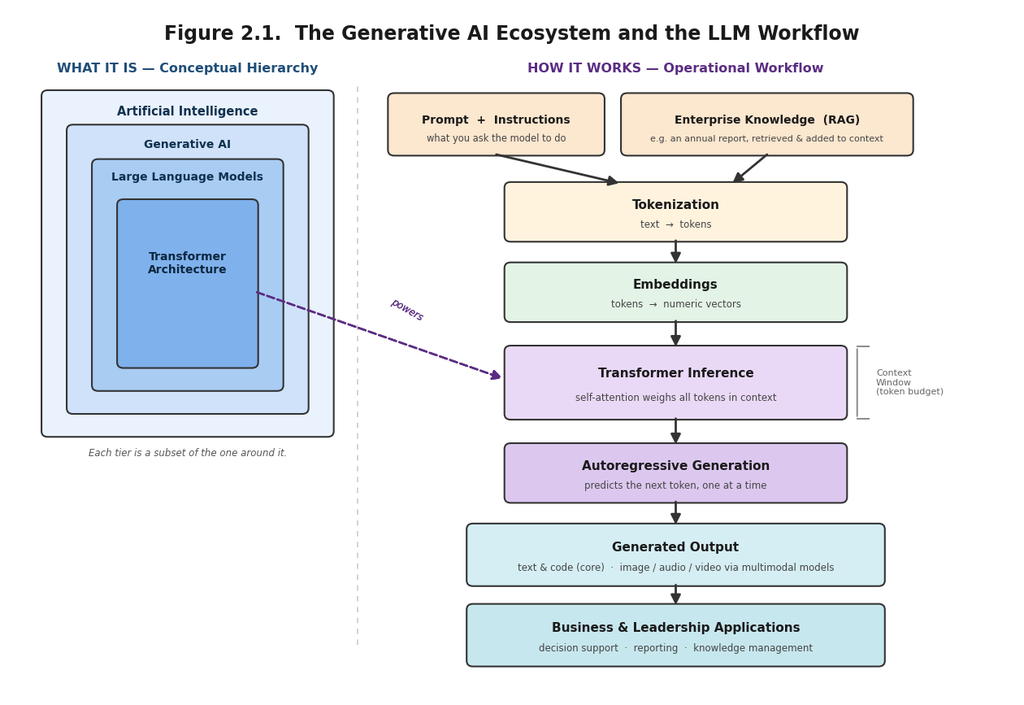

```python
import matplotlib.pyplot as plt
from matplotlib.patches import FancyBboxPatch, FancyArrowPatch

fig, ax = plt.subplots(figsize=(16, 11))
ax.set_xlim(0, 16)
ax.set_ylim(0, 12)
ax.axis("off")

EDGE = "#333333"

def box(x, y, w, h, color, lw=1.5, ec=EDGE):
    ax.add_patch(FancyBboxPatch(
        (x, y), w, h,
        boxstyle="round,pad=0.02,rounding_size=0.10",
        linewidth=lw, facecolor=color, edgecolor=ec, zorder=2))

def label(x, y, text, fs=10, weight="bold", color="#1a1a1a", ha="center", va="center"):
    ax.text(x, y, text, ha=ha, va=va, fontsize=fs,
            fontweight=weight, color=color, zorder=4)

def pipeline_box(x, y, w, h, color, title, sub=None, title_fs=11, sub_fs=8.5):
    box(x, y, w, h, color)
    if sub:
        label(x + w/2, y + h*0.62, title, fs=title_fs)
        ax.text(x + w/2, y + h*0.28, sub, ha="center", va="center",
                fontsize=sub_fs, color="#444444", zorder=4)
    else:
        label(x + w/2, y + h/2, title, fs=title_fs)

def arrow(x1, y1, x2, y2, color=EDGE, lw=2.0, style="-|>", dashed=False):
    ax.add_patch(FancyArrowPatch(
        (x1, y1), (x2, y2),
        arrowstyle=style, mutation_scale=18,
        linewidth=lw, color=color, zorder=3,
        linestyle="--" if dashed else "-",
        shrinkA=0, shrinkB=0))

label(8, 11.55, "Figure 2.1.  The Generative AI Ecosystem and the LLM Workflow", fs=17)

# Section headers
label(2.85, 10.95, "WHAT IT IS — Conceptual Hierarchy", fs=11.5, color="#1f4e79")
label(10.6, 10.95, "HOW IT WORKS — Operational Workflow", fs=11.5, color="#5b2d82")

# Light divider between the two regions
ax.plot([5.55, 5.55], [0.9, 10.7], color="#cccccc", lw=1.2, linestyle=(0, (4, 4)), zorder=1)

# Outer -> inner (decreasing lightness reads as "zooming in")
box(0.55, 4.55, 4.6, 6.0, "#EAF2FD")          # Artificial Intelligence
box(0.95, 4.95, 3.8, 5.0, "#CFE2FA")          # Generative AI
box(1.35, 5.35, 3.0, 4.0, "#A9CCF3")          # LLMs
box(1.75, 5.75, 2.2, 2.9, "#7FB1EC")          # Transformer Architecture

label(2.85, 10.20, "Artificial Intelligence", fs=10.5, color="#10314f")
label(2.85,  9.62, "Generative AI", fs=10, color="#10314f")
label(2.85,  9.05, "Large Language Models", fs=10, color="#10314f")
label(2.85,  7.55, "Transformer\nArchitecture", fs=10, color="#0d2740")

ax.text(2.85, 4.25, "Each tier is a subset of the one around it.",
        ha="center", va="center", fontsize=8.5, style="italic", color="#555555")

CX = 10.6           # pipeline center x
W  = 5.4            # standard box width
LX = CX - W/2       # left x of standard box

# ---- Inputs (two sources that get fed into the model) ----
box(6.05, 9.45, 3.4, 1.05, "#FCE7CF")
label(7.75, 10.05, "Prompt  +  Instructions", fs=10)
ax.text(7.75, 9.72, "what you ask the model to do", ha="center", va="center",
        fontsize=8.3, color="#444444", zorder=4)

box(9.75, 9.45, 4.6, 1.05, "#FCE7CF")
label(12.05, 10.05, "Enterprise Knowledge  (RAG)", fs=10)
ax.text(12.05, 9.72, "e.g. an annual report, retrieved & added to context",
        ha="center", va="center", fontsize=8.0, color="#444444", zorder=4)

# ---- Pipeline stages ----
pipeline_box(LX, 7.95, W, 1.0, "#FFF3DE", "Tokenization", "text  →  tokens")
pipeline_box(LX, 6.55, W, 1.0, "#E3F3E5", "Embeddings", "tokens  →  numeric vectors")
pipeline_box(LX, 4.85, W, 1.25, "#EAD9F6", "Transformer Inference",
             "self-attention weighs all tokens in context")
pipeline_box(LX, 3.40, W, 1.0, "#DCC8EF", "Autoregressive Generation",
             "predicts the next token, one at a time")
pipeline_box(7.30, 1.95, 6.6, 1.05, "#D5EEF4", "Generated Output",
             "text & code (core)  ·  image / audio / video via multimodal models")
pipeline_box(7.30, 0.55, 6.6, 1.05, "#C7E7EE", "Business & Leadership Applications",
             "decision support  ·  reporting  ·  knowledge management")

# ---- Context-window bracket around the inference stage ----
cw_x = LX + W + 0.18
ax.annotate("", xy=(cw_x, 4.85), xytext=(cw_x, 6.10),
            arrowprops=dict(arrowstyle="-", color="#8a8a8a", lw=1.4), zorder=2)
ax.plot([cw_x, cw_x+0.18], [4.85, 4.85], color="#8a8a8a", lw=1.4, zorder=2)
ax.plot([cw_x, cw_x+0.18], [6.10, 6.10], color="#8a8a8a", lw=1.4, zorder=2)
ax.text(cw_x + 0.30, 5.475, "Context\nWindow\n(token budget)", ha="left", va="center",
        fontsize=8.0, color="#666666", zorder=4)

# inputs -> tokenization
arrow(7.75, 9.45, CX - 0.9, 8.95)
arrow(12.05, 9.45, CX + 0.9, 8.95)
# main pipeline
arrow(CX, 7.95, CX, 7.55)            # tokenization -> embeddings
arrow(CX, 6.55, CX, 6.10)            # embeddings -> inference
arrow(CX, 4.85, CX, 4.40)            # inference -> generation
arrow(CX, 3.40, CX, 3.00)            # generation -> output
arrow(CX, 1.95, CX, 1.60)            # output -> applications

arrow(3.95, 7.05, LX - 0.05, 5.55, color="#5b2d82", lw=1.8, dashed=True)
ax.text(6.05, 6.55, "powers", fontsize=8.5, style="italic",
        color="#5b2d82", rotation=-30, zorder=4)
arrow(3.95, 7.05, LX - 0.05, 5.55, color="#5b2d82", lw=1.8, dashed=True)
ax.text(6.05, 6.55, "powers", fontsize=8.5, style="italic",
        color="#5b2d82", rotation=-30, zorder=4)

plt.savefig("images/Figure_2_1_Generative_AI_Ecosystem.png", dpi=300, bbox_inches="tight")
plt.show()
```

## 3. Interactive Demonstrations

### 3.1 Setting Up the Python Environment

In this section, we will prepare the Python environment used throughout this course. The notebook relies on several widely adopted open-source libraries for data manipulation, visualization, document processing, and interaction with Large Language Models (LLMs). These libraries will be reused throughout subsequent workshops, establishing a consistent computational environment for experimentation with Generative AI technologies.

The following code cell imports the core Python libraries required for Workshop 1.

```python
# Data manipulation
import pandas as pd
import numpy as np

# Visualization
import matplotlib.pyplot as plt

# Display options
from IPython.display import display, Markdown

# PDF processing
import fitz  # PyMuPDF

# File handling
from pathlib import Path

print("Environment successfully initialized.")
```

```
Environment successfully initialized.
```

### 3.2 Exploring the Microsoft Enterprise Knowledge Repository

Modern enterprise AI systems rarely rely solely on the knowledge contained within a pre-trained Large Language Model. Instead, organizations maintain collections of internal documents such as annual reports, policy manuals, technical documentation, financial reports, and knowledge bases. These repositories provide domain-specific information that complements the general knowledge of an LLM.

Throughout this course, we will use a simulated Microsoft Enterprise Knowledge Repository that contains authentic organizational documents. Although we will not build a Retrieval-Augmented Generation (RAG) system until later workshops, this repository will serve as the primary source of enterprise knowledge for our practical exercises. In this demonstration, we begin by exploring the repository structure and verifying that the required folders are available.

```python
from pathlib import Path

repo = Path("../Microsoft-Enterprise-Knowledge-Repository")

print("Microsoft Enterprise Knowledge Repository")
print("-" * 45)

for folder in sorted(repo.iterdir()):
    if folder.is_dir():
        print(f" {folder.name}")
```

```
Microsoft Enterprise Knowledge Repository
---------------------------------------------
 datasets
 images
 resources
```

### 3.3 Exploring Repository Resources

Enterprise AI systems rely on well-organized collections of organizational documents. Before applying Large Language Models (LLMs), it is essential to understand what information is available within the enterprise knowledge repository.

In this demonstration, we will examine the contents of the **resources** folder. Throughout this course, this directory will contain organizational documents such as annual reports, policy manuals, AI governance documents, technical reports, and other business materials that will be used in subsequent workshops.

The objective of this exercise is to familiarize students with the repository structure and reinforce the importance of high-quality organizational data as the foundation for enterprise AI applications.

```python
# Define the path to the resources folder
resource_path = repository_path / "resources"

print("Contents of the Resources Directory")
print("-" * 50)

# Display only enterprise documents
documents = sorted([
    document for document in resource_path.iterdir()
    if document.is_file() and document.suffix.lower() in [".docx", ".pdf", ".txt"]
])

if len(documents) == 0:
    print("No enterprise documents are currently available.")
else:
    for document in documents:
        print(document.name)
```

```
Contents of the Resources Directory
--------------------------------------------------
Microsoft_10K_2024.docx
Microsoft_Annual_Report_2024.docx
Microsoft_Shareholder_Letter_2024.docx
```

### 3.4 Loading the Microsoft Annual Report

Large Language Models derive value from the information contained within organizational documents. Before an LLM can analyze or reason over enterprise knowledge, the documents must first be loaded into the computational environment.

In this demonstration, we will load Microsoft's 2024 Annual Report from the Microsoft Enterprise Knowledge Repository. Although we will not yet perform advanced natural language processing, this exercise introduces the first step in every enterprise AI workflow: accessing and preparing organizational documents for analysis.

Understanding how enterprise documents are loaded and managed provides the foundation for later workshops on document processing, Retrieval-Augmented Generation (RAG), semantic search, and knowledge management.

```python
from pathlib import Path

# Define the path to the Microsoft Annual Report
annual_report = (
    repository_path /
    "resources" /
    "Microsoft_Annual_Report_2024.docx"
)

print("Loading Enterprise Document")
print("-" * 50)

if annual_report.exists():
    print("Status        : Successfully located")
    print(f"Document      : {annual_report.name}")
    print(f"File Type     : {annual_report.suffix}")
    print(f"File Size     : {annual_report.stat().st_size / 1024:.2f} KB")
else:
    print("The Microsoft Annual Report could not be located.")
```

```
Loading Enterprise Document
--------------------------------------------------
Status        : Successfully located
Document      : Microsoft_Annual_Report_2024.docx
File Type     : .docx
File Size     : 1753.17 KB
```

#### Discussion

Before a Large Language Model can analyze enterprise information, it must first access the underlying organizational documents. This step verifies that the required document exists within the Microsoft Enterprise Knowledge Repository and provides basic information about the file.

In later workshops, this document will serve as the primary knowledge source for document parsing, text extraction, prompt engineering, semantic search, embeddings, and Retrieval-Augmented Generation (RAG). Establishing a well-organized repository of enterprise documents is therefore an essential prerequisite for developing practical AI solutions.

### 3.5 Understanding Unstructured Text Data

Large Language Models (LLMs) do not directly process Microsoft Word documents, PDF files, spreadsheets, or webpages. Instead, these documents must first be converted into plain text before they can be analyzed. This process is a fundamental step in Natural Language Processing (NLP) and forms the foundation of enterprise AI systems.

Unstructured text refers to information that does not follow a predefined database schema. Annual reports, emails, contracts, technical documentation, meeting minutes, and organizational policies are all examples of unstructured data. Although these documents contain valuable knowledge, they require preprocessing before they can be used by machine learning models and LLMs.

In this demonstration, we will extract text from the Microsoft Annual Report and examine the first portion of the document. This exercise illustrates how enterprise documents are transformed into machine-readable text prior to prompt engineering, semantic search, embeddings, and Retrieval-Augmented Generation (RAG).

```python
from docx import Document

# Load the Microsoft Annual Report
document = Document(annual_report)

# Extract non-empty paragraphs
paragraphs = [
    paragraph.text.strip()
    for paragraph in document.paragraphs
    if paragraph.text.strip()
]

print("Enterprise Document Summary")
print("-" * 50)
print(f"Document Name     : {annual_report.name}")
print(f"Document Type     : {annual_report.suffix}")
print(f"Total Paragraphs  : {len(paragraphs)}")
print(f"File Size         : {annual_report.stat().st_size / 1024:.2f} KB")
```

```
Enterprise Document Summary
--------------------------------------------------
Document Name     : Microsoft_Annual_Report_2024.docx
Document Type     : .docx
Total Paragraphs  : 942
File Size         : 1753.17 KB
```

```python
print("Preview of the Microsoft Annual Report")
print("-" * 80)

for i, paragraph in enumerate(paragraphs[:10], start=1):
    print(f"\nParagraph {i}")
    print(paragraph)
```

```
Preview of the Microsoft Annual Report
--------------------------------------------------------------------------------

Paragraph 1
Dear shareholders, colleagues, customers, and partners:

Paragraph 2
Fiscal year 2024 was a pivotal year for Microsoft. We entered our 50th year as a company and the second year of the AI platform shift. With these milestones, I’ve found myself reflecting on how Microsoft has remained a consequential company decade after decade in an industry with no franchise value.…

Paragraph 3
Microsoft has been a platform and tools company from the start. We were founded in 1975 with a belief in creating technology that would enable others to create their own. And, nearly 50 years later, this belief remains at the heart of our mission to empower every person and every organization on the…

Paragraph 4
This year, we moved from talking about AI to helping our customers translate it into real outcomes—one person, one organization, one institution, and one country at a time. We have made remarkable progress on this front across every industry. For example:

Paragraph 5
•	Coles is generating 1.6 billion daily AI predictions across 850 Australian stores, ensuring every shopper finds what they need.

Paragraph 6
•	Unilever is performing thousands of simulations with AI in the time it would take to run tens of laboratory experiments, as it accelerates its product development.

Paragraph 7
•	Developers at Itaú, Brazil’s largest private bank, are coding more efficiently using our AI pair programmer, GitHub Copilot.

Paragraph 8
•	Khan Academy is making tutoring more accessible for students and helping teachers plan more creative lessons, using our small language model Phi.

Paragraph 9
•	Aquafarmers in Indonesia are improving their yields, thanks to an app built with the Azure OpenAI Service, as well as Azure IoT.

Paragraph 10
•	In Kenya, street vendors now have access to credit for the first time, thanks to M-Kopa, a social enterprise using Azure ML to do its forecasting.
```

#### Discussion

Although the Microsoft Annual Report is stored as a Microsoft Word document, it has now been transformed into a collection of plain-text paragraphs. This representation allows the document to be processed computationally using Natural Language Processing (NLP) techniques and Large Language Models (LLMs).

At this stage, the document remains unstructured text. In subsequent demonstrations, we will learn how this text is prepared through tokenization, embedded into numerical vector representations, and incorporated into enterprise AI workflows such as semantic search and Retrieval-Augmented Generation (RAG).

### 3.6 Prompt Engineering Demonstration

Prompt engineering is the process of designing clear and effective instructions that guide a Large Language Model (LLM) toward producing accurate, relevant, and useful responses. The quality of an LLM's output depends not only on the underlying model but also on the quality of the prompt provided by the user.

Enterprise AI applications frequently use organizational documents such as annual reports, policy manuals, contracts, and technical documentation as contextual information. Rather than asking vague questions, users provide well-structured prompts that specify the task, the desired audience, the expected format, and any relevant business context.

In this demonstration, we will examine several prompts based on the Microsoft Annual Report. Although we are not yet sending these prompts to an LLM, the examples illustrate how prompt quality influences the effectiveness of AI-assisted decision making.

```python
# Example prompts based on the Microsoft Annual Report

basic_prompt = """
Summarize the Microsoft Annual Report.
"""

improved_prompt = """
You are a senior business analyst.

Using the Microsoft Annual Report, summarize Microsoft's strategic priorities,
major financial achievements, and artificial intelligence initiatives.

Present the summary as five concise bullet points suitable for executive leadership.
"""

advanced_prompt = """
Assume you are advising the Chief Executive Officer.

Analyze the Microsoft Annual Report and identify:

1. Three strategic priorities.
2. Three business risks.
3. Three opportunities created by Generative AI.
4. Recommendations for executive decision making.

Present your findings using clear headings and concise business language.
"""

print("Basic Prompt")
print("-" * 60)
print(basic_prompt)

print("\nImproved Prompt")
print("-" * 60)
print(improved_prompt)

print("\nAdvanced Prompt")
print("-" * 60)
print(advanced_prompt)
```

```
Basic Prompt
------------------------------------------------------------

Summarize the Microsoft Annual Report.


Improved Prompt
------------------------------------------------------------

You are a senior business analyst.

Using the Microsoft Annual Report, summarize Microsoft's strategic priorities,
major financial achievements, and artificial intelligence initiatives.

Present the summary as five concise bullet points suitable for executive leadership.


Advanced Prompt
------------------------------------------------------------

Assume you are advising the Chief Executive Officer.

Analyze the Microsoft Annual Report and identify:

1. Three strategic priorities.
2. Three business risks.
3. Three opportunities created by Generative AI.
4. Recommendations for executive decision making.

Present your findings using clear headings and concise business language.
```

#### Discussion

These examples demonstrate that prompt engineering extends beyond simply asking a question. Effective prompts provide context, define the user's role, specify the required task, identify the intended audience, and describe the desired output format.

As prompts become more detailed and structured, Large Language Models are better able to generate responses that align with organizational objectives and support informed decision making. Throughout this course, prompt engineering will become an essential skill for interacting effectively with enterprise AI systems.

### 3.7 Tokenization Demonstration

Although humans read documents as words, sentences, and paragraphs, Large Language Models process text as **tokens**. A token is the basic unit of text that an LLM uses during training and inference. Depending on the tokenizer, a token may represent an entire word, part of a word, punctuation, or even whitespace.

Tokenization is the first computational step performed before a prompt reaches the transformer architecture. Every prompt and every generated response is converted into a sequence of tokens that the model can process numerically.

In this demonstration, we illustrate the concept of tokenization using a simple whitespace tokenizer. Although modern LLMs employ more sophisticated tokenization algorithms, this example provides an intuitive understanding of how textual information is transformed into smaller computational units.

```python
sample_text = """
Microsoft is investing heavily in Artificial Intelligence to improve
productivity, cloud computing, cybersecurity, and enterprise innovation.
"""

print("Original Text")
print("-" * 60)
print(sample_text)

tokens = sample_text.split()

print("\nTokenized Text")
print("-" * 60)

for i, token in enumerate(tokens, start=1):
    print(f"{i:2}. {token}")

print("\nTotal Tokens:", len(tokens))
```

```
Original Text
------------------------------------------------------------

Microsoft is investing heavily in Artificial Intelligence to improve
productivity, cloud computing, cybersecurity, and enterprise innovation.


Tokenized Text
------------------------------------------------------------
 1. Microsoft
 2. is
 3. investing
 4. heavily
 5. in
 6. Artificial
 7. Intelligence
 8. to
 9. improve
10. productivity,
11. cloud
12. computing,
13. cybersecurity,
14. and
15. enterprise
16. innovation.

Total Tokens: 16
```

```python
sample_paragraph = paragraphs[10]

print("Enterprise Text Sample")
print("-" * 60)
print(sample_paragraph)

tokens = sample_paragraph.split()

print("\nNumber of Words (Approximate Tokens)")
print("-" * 60)
print(len(tokens))
```

```
Enterprise Text Sample
------------------------------------------------------------
•	And enterprise customers and their employees around the world, from Amgen and Disney, to Finastra and Vodafone, are using Microsoft 365 Copilot to become more creative and productive.

Number of Words (Approximate Tokens)
------------------------------------------------------------
29
```

#### Discussion

This demonstration uses a simple whitespace tokenizer to illustrate the concept of tokenization. Modern Large Language Models employ specialized tokenization algorithms such as Byte Pair Encoding (BPE), WordPiece, or SentencePiece, which often divide words into smaller subword units rather than separating text solely by spaces.

Although the exact number of tokens produced by an LLM tokenizer differs from this simplified example, the underlying concept remains the same: textual information must first be converted into a sequence of tokens before it can be processed by the transformer architecture. Understanding tokenization is essential because model context windows, computational cost, inference speed, and API pricing are typically measured in tokens rather than words or pages.

### 3.8 AI-Powered Text Summarization

One of the most common applications of Generative Artificial Intelligence is the ability to summarize lengthy documents into concise and meaningful insights. Business leaders frequently rely on summaries of annual reports, financial statements, policy documents, and technical reports to support strategic decision-making.

```python
# Combine all extracted paragraphs into a single document

document_text = "\n".join(paragraphs)

print("Microsoft Annual Report")
print("-" * 60)
print(f"Total paragraphs : {len(paragraphs)}")
print(f"Total characters : {len(document_text):,}")
print(f"Approximate words: {len(document_text.split()):,}")
```

```
Microsoft Annual Report
------------------------------------------------------------
Total paragraphs : 942
Total characters : 236,211
Approximate words: 34,860
```

```python
print("Document Preview")
print("-" * 60)

preview = document_text[:2000]

print(preview)
```

```
Document Preview
------------------------------------------------------------
Dear shareholders, colleagues, customers, and partners:
Fiscal year 2024 was a pivotal year for Microsoft. We entered our 50th year as a company and the second year of the AI platform shift. With these milestones, I’ve found myself reflecting on how Microsoft has remained a consequential company decade after decade in an industry with no franchise value.…
Microsoft has been a platform and tools company from the start. We were founded in 1975 with a belief in creating technology that would enable others to create their own. And, nearly 50 years later, this belief remains at the heart of our mission to empower every person and every organization on the…
This year, we moved from talking about AI to helping our customers translate it into real outcomes—one person, one organization, one institution, and one country at a time. We have made remarkable progress on this front across every industry. For example:
•	Coles is generating 1.6 billion daily AI predictions across 850 Australian stores, ensuring every shopper finds what they need.
•	Unilever is performing thousands of simulations with AI in the time it would take to run tens of laboratory experiments, as it accelerates its product development.
•	Developers at Itaú, Brazil’s largest private bank, are coding more efficiently using our AI pair programmer, GitHub Copilot.
•	Khan Academy is making tutoring more accessible for students and helping teachers plan more creative lessons, using our small language model Phi.
•	Aquafarmers in Indonesia are improving their yields, thanks to an app built with the Azure OpenAI Service, as well as Azure IoT.
•	In Kenya, street vendors now have access to credit for the first time, thanks to M-Kopa, a social enterprise
```

```python
print("Representative Summary")
print("-" * 60)

summary = paragraphs[:5]

for i, paragraph in enumerate(summary, start=1):
    print(f"\nSummary Paragraph {i}")
    print(paragraph)
```

```
Representative Summary
------------------------------------------------------------

Summary Paragraph 1
Dear shareholders, colleagues, customers, and partners:

Summary Paragraph 2
Fiscal year 2024 was a pivotal year for Microsoft. We entered our 50th year as a company and the second year of the AI platform shift. With these milestones, I’ve found myself reflecting on how Microsoft has remained a consequential company decade after decade in an industry with no franchise value.…

Summary Paragraph 3
Microsoft has been a platform and tools company from the start. We were founded in 1975 with a belief in creating technology that would enable others to create their own. And, nearly 50 years later, this belief remains at the heart of our mission to empower every person and every organization on the…

Summary Paragraph 4
This year, we moved from talking about AI to helping our customers translate it into real outcomes—one person, one organization, one institution, and one country at a time. We have made remarkable progress on this front across every industry. For example:

Summary Paragraph 5
•	Coles is generating 1.6 billion daily AI predictions across 850 Australian stores, ensuring every shopper finds what they need.
```

#### Discussion

Enterprise documents often contain hundreds of pages and thousands of paragraphs. Reading every page manually can be time-consuming for business leaders and analysts. Document summarization addresses this challenge by reducing large volumes of information into concise, meaningful insights.

The approach demonstrated here represents a simplified form of extractive summarization, where representative text is selected directly from the source document. Modern Large Language Models extend this capability through abstractive summarization, generating entirely new text that preserves the meaning of the original document while improving readability and coherence.

Throughout the remainder of this course, students will build increasingly sophisticated summarization pipelines by integrating prompt engineering, transformer models, Retrieval-Augmented Generation (RAG), and enterprise knowledge repositories.

### 3.9 Business Leadership Example

Generative Artificial Intelligence is transforming how organizational leaders access information and make strategic decisions. Rather than manually reviewing hundreds of pages of reports, executives can use Large Language Models to summarize enterprise documents, identify emerging trends, evaluate organizational risks, and generate evidence-based recommendations.

Consider the Microsoft Annual Report as an example. A Chief Executive Officer (CEO), Chief Financial Officer (CFO), or Chief Information Officer (CIO) may seek concise answers to strategic questions rather than reading the complete document. Large Language Models assist decision makers by retrieving relevant information, synthesizing key insights, and presenting results in a clear and actionable format.

The following scenario demonstrates how enterprise documents can support executive decision-making through AI-assisted analysis.

```python
business_scenario = """
Scenario

You are the Chief Executive Officer (CEO) of Microsoft preparing for the
annual Board of Directors meeting.

The Board has requested a concise briefing based on the company's Annual Report.

Your objectives are to:

• Review Microsoft's strategic priorities.
• Identify major business opportunities.
• Evaluate organizational risks.
• Assess the company's Artificial Intelligence initiatives.
• Recommend future strategic investments.

A Large Language Model can assist by analyzing the annual report,
summarizing key findings, and generating evidence-based recommendations
to support executive decision making.
"""

print(business_scenario)
```

```
Scenario

You are the Chief Executive Officer (CEO) of Microsoft preparing for the
annual Board of Directors meeting.

The Board has requested a concise briefing based on the company's Annual Report.

Your objectives are to:

• Review Microsoft's strategic priorities.
• Identify major business opportunities.
• Evaluate organizational risks.
• Assess the company's Artificial Intelligence initiatives.
• Recommend future strategic investments.

A Large Language Model can assist by analyzing the annual report,
summarizing key findings, and generating evidence-based recommendations
to support executive decision making.
```

```python
executive_questions = [
    "What are Microsoft's three most important strategic priorities?",
    "How is Microsoft investing in Artificial Intelligence?",
    "What business risks require executive attention?",
    "Which business segments are experiencing the greatest growth?",
    "What recommendations would strengthen Microsoft's competitive advantage?"
]

print("Executive Decision-Making Questions")
print("-" * 60)

for number, question in enumerate(executive_questions, start=1):
    print(f"{number}. {question}")
```

```
Executive Decision-Making Questions
------------------------------------------------------------
1. What are Microsoft's three most important strategic priorities?
2. How is Microsoft investing in Artificial Intelligence?
3. What business risks require executive attention?
4. Which business segments are experiencing the greatest growth?
5. What recommendations would strengthen Microsoft's competitive advantage?
```

#### Discussion

This scenario illustrates how enterprise leaders can leverage Large Language Models to transform extensive organizational documents into actionable business intelligence. Rather than replacing human judgment, Generative AI augments executive decision-making by accelerating information retrieval, summarizing complex reports, identifying strategic themes, and supporting evidence-based recommendations.

Throughout this course, students will progressively develop the technical knowledge required to build these enterprise AI capabilities. Beginning with document preparation and prompt engineering in Workshop 1, subsequent workshops will introduce transformer architectures, embeddings, semantic search, Retrieval-Augmented Generation (RAG), and advanced enterprise applications that enable organizations to derive greater value from their knowledge assets.

## 4. Microsoft Enterprise Case Study

### 4.1 Company Overview

Throughout this course, Microsoft Corporation serves as the primary enterprise case study for exploring the practical applications of Generative Artificial Intelligence (GenAI) and Large Language Models (LLMs). Microsoft provides an ideal organizational context because it is one of the world's largest technology companies, a recognized leader in enterprise cloud computing, and a major contributor to the rapid advancement of artificial intelligence technologies.

Founded in 1975 by Bill Gates and Paul Allen, Microsoft has evolved from a software company into a global technology enterprise whose products and services support governments, businesses, educational institutions, and individuals worldwide. Today, Microsoft's portfolio includes Windows, Microsoft 365, Azure, GitHub, LinkedIn, Dynamics 365, Xbox, and the Microsoft Copilot family of AI-powered applications. Through its multibillion-dollar investment in OpenAI and the integration of Generative AI capabilities across its products, Microsoft has positioned itself as a leader in enterprise AI adoption.

From an educational perspective, Microsoft provides an excellent case study because the company publicly releases comprehensive corporate documents, including annual reports, SEC filings, shareholder letters, Responsible AI publications, technical documentation, and cloud architecture resources. These authentic enterprise documents enable students to explore how Large Language Models interact with organizational knowledge while developing practical skills in prompt engineering, document analysis, enterprise search, and AI-assisted decision making.

Throughout this course, students will use the Microsoft Enterprise Knowledge Repository developed for this notebook to simulate real-world enterprise AI workflows. Rather than relying on synthetic examples, students will analyze authentic organizational documents to understand how Generative AI supports strategic leadership, knowledge management, and organizational decision making.

```python
print("Microsoft Enterprise Knowledge Repository")
print("-" * 50)

print("Enterprise Documents Available")
print()

for document in documents:
    print(document.name)
```

```
Microsoft Enterprise Knowledge Repository
--------------------------------------------------
Enterprise Documents Available

Microsoft_10K_2024.docx
Microsoft_Annual_Report_2024.docx
Microsoft_Shareholder_Letter_2024.docx
```

### 4.2 Why Microsoft?

Selecting an appropriate organizational case study is essential for understanding how Generative Artificial Intelligence is implemented in real-world enterprise environments. Microsoft provides an exceptional example because it integrates Large Language Models (LLMs), cloud computing, enterprise software, cybersecurity, and responsible AI governance within a single organizational ecosystem. As a result, students can examine both the technical foundations and strategic implications of enterprise AI using authentic organizational documents and publicly available resources.

Several factors make Microsoft particularly suitable for this course.

**Leadership in Artificial Intelligence.** Microsoft has emerged as one of the world's leading investors in artificial intelligence through its strategic partnership with OpenAI and its continued integration of Generative AI technologies across Microsoft 365, Azure, GitHub, Dynamics 365, Bing, and the Microsoft Copilot ecosystem. These initiatives demonstrate how organizations are embedding AI capabilities into everyday business operations.

**Enterprise Cloud Computing.** Microsoft's Azure platform provides one of the largest cloud infrastructures supporting enterprise AI applications. Azure AI services, Azure OpenAI Service, and Microsoft's Responsible AI framework illustrate how organizations deploy scalable and secure AI solutions for businesses across multiple industries.

**Availability of High-Quality Enterprise Documents.** Unlike many organizations, Microsoft publishes extensive corporate documentation that includes annual reports, SEC filings, shareholder letters, Responsible AI reports, sustainability reports, technical documentation, and governance frameworks. These authentic documents provide an excellent foundation for studying enterprise knowledge management, document analysis, prompt engineering, and Retrieval-Augmented Generation (RAG).

**Commitment to Responsible AI.** Microsoft has been a leading advocate for responsible AI development by emphasizing fairness, reliability, privacy, security, transparency, accountability, and inclusiveness. These principles provide valuable examples for understanding the ethical and governance considerations associated with deploying AI systems within organizations.

Throughout this course, Microsoft serves not simply as an example company, but as a realistic enterprise environment in which students will explore how Generative AI supports knowledge management, executive decision-making, organizational innovation, and digital transformation.

```python
microsoft_ai_products = {
    "Microsoft Copilot": "AI-powered productivity assistant",
    "Azure OpenAI Service": "Enterprise platform for deploying Large Language Models",
    "GitHub Copilot": "AI-assisted software development",
    "Microsoft 365 Copilot": "AI-enhanced productivity applications",
    "Dynamics 365 Copilot": "AI support for business applications"
}

print("Microsoft Enterprise AI Ecosystem")
print("-" * 60)

for product, description in microsoft_ai_products.items():
    print(f"{product}")
    print(f"   {description}\n")
```

```
Microsoft Enterprise AI Ecosystem
------------------------------------------------------------
Microsoft Copilot
   AI-powered productivity assistant

Azure OpenAI Service
   Enterprise platform for deploying Large Language Models

GitHub Copilot
   AI-assisted software development

Microsoft 365 Copilot
   AI-enhanced productivity applications

Dynamics 365 Copilot
   AI support for business applications
```

#### Discussion

The examples presented above demonstrate that Microsoft's AI strategy extends well beyond experimental research. Instead, Generative AI has been integrated across productivity software, cloud services, software development, enterprise resource planning, and business intelligence platforms. This broad adoption illustrates how Large Language Models are becoming foundational technologies for modern organizations.

Throughout this course, students will analyze Microsoft's enterprise documents to better understand how AI supports organizational strategy, innovation, and decision-making across multiple business functions.

### 4.3 Annual Report Overview

An annual report is one of the most comprehensive sources of organizational information available to investors, regulators, business leaders, and other stakeholders. Publicly traded companies publish annual reports to communicate their financial performance, strategic direction, governance practices, business risks, and future opportunities. Because these reports combine financial, operational, and strategic information within a single document, they represent valuable enterprise knowledge resources for Large Language Models (LLMs) and other AI-driven decision support systems.

From the perspective of enterprise artificial intelligence, annual reports provide rich collections of unstructured text that can be transformed into machine-readable knowledge. Business leaders frequently rely on AI systems to summarize lengthy reports, identify strategic priorities, analyze organizational risks, compare financial performance, and generate executive briefings that support informed decision-making.

Throughout this course, the Microsoft Annual Report serves as the primary enterprise document for demonstrating document processing, prompt engineering, text summarization, semantic search, and Retrieval-Augmented Generation (RAG). Rather than working with synthetic examples, students will explore authentic corporate information similar to the documents encountered in modern enterprise environments.

```python
print("Microsoft Annual Report Overview")
print("-" * 60)

print(f"Document Name      : {annual_report.name}")
print(f"File Type          : {annual_report.suffix}")
print(f"Total Paragraphs   : {len(paragraphs)}")
print(f"Approximate Words  : {len(document_text.split()):,}")
print(f"Characters         : {len(document_text):,}")
```

```
Microsoft Annual Report Overview
------------------------------------------------------------
Document Name      : Microsoft_Annual_Report_2024.docx
File Type          : .docx
Total Paragraphs   : 942
Approximate Words  : 34,860
Characters         : 236,211
```

#### Discussion

Annual reports contain a unique combination of structured and unstructured information. Financial statements provide structured numerical data, while executive narratives, strategic discussions, governance reports, and risk disclosures consist primarily of unstructured text. Together, these complementary data types make annual reports an ideal resource for enterprise AI applications.

Throughout this course, students will use the Microsoft Annual Report to explore how Large Language Models transform enterprise documents into actionable knowledge. By combining prompt engineering, text processing, semantic search, and Retrieval-Augmented Generation (RAG), AI systems can help organizational leaders identify important information more efficiently while supporting evidence-based strategic decision-making.

### 4.4 Executive Leadership Perspectives

One of the defining characteristics of Generative Artificial Intelligence is its ability to support decision-making across multiple levels of an organization. While Large Language Models process the same underlying enterprise knowledge, the questions posed to the AI system vary depending on the responsibilities of the decision maker.

For example, a Chief Executive Officer (CEO) may focus on organizational strategy and competitive positioning, whereas a Chief Financial Officer (CFO) is primarily concerned with financial performance, risk management, and investment decisions. Similarly, a Chief Information Officer (CIO) may evaluate technology strategy and cybersecurity risks, while a Chief Human Resources Officer (CHRO) examines workforce development and organizational change.

This illustrates an important principle of enterprise AI: the value of an LLM depends not only on the information available within the enterprise knowledge repository, but also on the quality of the questions being asked. Different leadership roles require different perspectives, even when analyzing the same organizational documents.

The Microsoft Annual Report demonstrates this principle by providing a common source of enterprise knowledge that supports a wide range of strategic, operational, financial, and technological decisions.

```python
leadership_roles = {
    "Chief Executive Officer (CEO)": [
        "What are Microsoft's long-term strategic priorities?",
        "What opportunities should receive additional investment?"
    ],
    "Chief Financial Officer (CFO)": [
        "What financial risks are discussed in the annual report?",
        "How is Microsoft's financial performance changing?"
    ],
    "Chief Information Officer (CIO)": [
        "How is Microsoft integrating Artificial Intelligence into its business?",
        "What technology investments support future growth?"
    ],
    "Chief Human Resources Officer (CHRO)": [
        "How might Generative AI affect workforce development?",
        "What organizational capabilities are needed for AI adoption?"
    ]
}

print("Executive Leadership Perspectives")
print("-" * 70)

for role, questions in leadership_roles.items():
    print(f"\n{role}")
    for question in questions:
        print(f"  • {question}")
```

```
Executive Leadership Perspectives
----------------------------------------------------------------------

Chief Executive Officer (CEO)
  • What are Microsoft's long-term strategic priorities?
  • What opportunities should receive additional investment?

Chief Financial Officer (CFO)
  • What financial risks are discussed in the annual report?
  • How is Microsoft's financial performance changing?

Chief Information Officer (CIO)
  • How is Microsoft integrating Artificial Intelligence into its business?
  • What technology investments support future growth?

Chief Human Resources Officer (CHRO)
  • How might Generative AI affect workforce development?
  • What organizational capabilities are needed for AI adoption?
```

### Reflection

This case study demonstrates that enterprise AI systems do not produce a single "correct" answer for every user. Instead, the value of a Large Language Model depends on the organizational context, the available enterprise knowledge, and the objectives of the individual using the system.

Throughout this course, students will assume different organizational leadership roles and apply Generative AI techniques to analyze authentic enterprise documents, develop strategic recommendations, and support evidence-based decision-making. By combining technical knowledge with leadership perspectives, students will gain a practical understanding of how Large Language Models create value within modern organizations.

## 5. Summary

This workshop introduced the foundational concepts of Generative Artificial Intelligence (GenAI) and Large Language Models (LLMs), establishing the theoretical and practical framework that will guide the remainder of this course. Students explored the evolution of artificial intelligence, developed a common vocabulary of essential terminology, and examined the technologies that enable modern LLMs to generate human-like text and support intelligent decision-making.

Through a series of interactive demonstrations, students gained hands-on experience with a simulated enterprise AI environment. Using the Microsoft Enterprise Knowledge Repository, students learned how organizational documents are managed, loaded, and transformed into machine-readable text for analysis. They explored prompt engineering, tokenization, and AI-powered text summarization while developing an understanding of how enterprise knowledge supports Large Language Models in real-world organizational settings.

The Microsoft Enterprise Case Study demonstrated that enterprise AI extends beyond technical implementation. By analyzing authentic Microsoft corporate documents, students examined how Generative AI can assist organizational leaders in summarizing complex information, identifying strategic priorities, evaluating business risks, and supporting evidence-based decision-making. This case study reinforced the importance of combining technical knowledge with leadership perspectives when designing and implementing enterprise AI solutions.

As organizations increasingly integrate Generative AI into business operations, professionals must understand not only how Large Language Models function but also how enterprise knowledge, prompt design, governance, and organizational context influence AI-generated outcomes. Throughout this course, students will continue to build upon these foundational concepts by exploring transformer architectures, embeddings, semantic search, vector databases, Retrieval-Augmented Generation (RAG), and advanced enterprise AI applications.

By the end of this workshop, students should be able to:

- Explain the fundamental concepts of Generative Artificial Intelligence and Large Language Models.
- Define the key terminology associated with modern enterprise AI systems.
- Describe how enterprise knowledge repositories support AI-powered applications.
- Load, examine, and analyze authentic organizational documents.
- Explain the roles of prompt engineering and tokenization within the LLM workflow.
- Recognize how Generative AI supports organizational leadership and strategic decision-making.
- Understand the importance of responsible, evidence-based AI implementation in enterprise environments.

The knowledge and practical skills developed in this workshop provide the conceptual foundation for the remaining workshops, where students will progressively design, evaluate, and implement more sophisticated Large Language Model applications using authentic enterprise data and real-world business scenarios.

## 6. References, Further Reading, and Data Sources

### 6.1 References

Bommasani, R., Hudson, D. A., Adeli, E., et al. (2021). *On the opportunities and risks of foundation models*. Stanford Center for Research on Foundation Models.

Brown, T. B., Mann, B., Ryder, N., et al. (2020). Language models are few-shot learners. *Advances in Neural Information Processing Systems, 33*, 1877–1901.

Brynjolfsson, E., & McAfee, A. (2017). *Machine, platform, crowd: Harnessing our digital future*. W. W. Norton & Company.

Davenport, T. H., & Ronanki, R. (2018). Artificial intelligence for the real world. *Harvard Business Review, 96*(1), 108–116.

Goodfellow, I., Bengio, Y., & Courville, A. (2016). *Deep learning*. MIT Press.

Kaplan, J., McCandlish, S., Henighan, T., et al. (2020). Scaling laws for neural language models. *arXiv preprint arXiv:2001.08361*.

Russell, S., & Norvig, P. (2021). *Artificial intelligence: A modern approach* (4th ed.). Pearson.

Vaswani, A., Shazeer, N., Parmar, N., et al. (2017). Attention is all you need. *Advances in Neural Information Processing Systems, 30*.

### 6.2 Further Reading

Bender, E. M., Gebru, T., McMillan-Major, A., & Shmitchell, S. (2021). On the dangers of stochastic parrots: Can language models be too big? *Proceedings of the 2021 ACM Conference on Fairness, Accountability, and Transparency*.

Bommasani, R., et al. (2021). *On the opportunities and risks of foundation models*. Stanford University.

Jurafsky, D., & Martin, J. H. (2025). *Speech and language processing* (Draft, 3rd ed.). Stanford University.

Microsoft. (2024). *Responsible AI Standard (Version 2)*.

OpenAI. (2023). *GPT-4 Technical Report*. arXiv.

OpenAI. (2024). *Introducing GPT-4o*.

Stanford Institute for Human-Centered Artificial Intelligence (HAI). (2025). *AI Index Report 2025*.

### 6.3 Data Sources

The enterprise documents used throughout this workshop were obtained from publicly available Microsoft corporate publications and are included solely for educational purposes.

Primary Enterprise Documents

- Microsoft Annual Report 2024
- Microsoft Form 10-K (Fiscal Year 2024)
- Microsoft Shareholder Letter 2024

Additional Microsoft Resources

- Microsoft Responsible AI documentation
- Microsoft AI documentation
- Microsoft Azure documentation
- Microsoft Investor Relations publications

These documents collectively form the Microsoft Enterprise Knowledge Repository used throughout this course to demonstrate enterprise document analysis, prompt engineering, document summarization, semantic search, and Retrieval-Augmented Generation (RAG).

### License

MIT License  
Copyright (c) 2026 Dr. Eskinder Belete

**Author**: Dr. Eskinder Belete  
**Copyright**: © 2026 Eskinder B. All rights reserved.